# NamVien_906178035_Stats101C

**(1) Reproduce the Bias-Variance plot in the lecture note using y = sin(x) + cos(x) + exp**

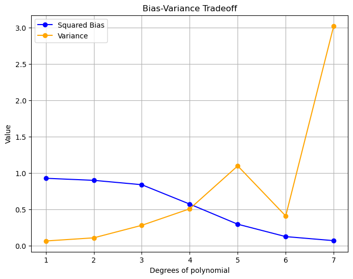

```python
import numpy as np
import matplotlib.pyplot as plt
from sklearn.linear_model import LinearRegression

np.random.seed(2)

def true_function(x):
    """The true underlying function: sin(x) + cos(x)."""
    return np.sin(x) + np.cos(x)

def generate_data(n_datasets, n_samples, noise_std=0.20):
    """Generates multiple datasets with noise."""
    x = np.random.uniform(-2 * np.pi, 2 * np.pi,
                          size=(n_datasets, n_samples))
    noise = np.random.normal(0, noise_std,
                             size=(n_datasets, n_samples))
    y = true_function(x) + noise
    return x, y

def generate_test_data(n_samples):
    """Generates test data without noise."""
    x_test = np.random.uniform(-2 * np.pi, 2 * np.pi, size=n_samples)
    y_test = true_function(x_test)
    return x_test, y_test

def create_polynomial_features(x, degree):
    """Manually creates a polynomial feature matrix
    up to a given degree."""
    X_poly = np.ones((len(x), degree + 1))
    for i in range(1, degree + 1):
        X_poly[:, i] = x ** i
    return X_poly

def fit_polynomial_model(x_train, y_train, x_test, degree):
    """Fits polynomial regression models for each dataset
    and returns predictions on test data."""
    n_datasets = x_train.shape[0]
    y_pred_all = []
    X_test_poly = create_polynomial_features(x_test, degree)
    for i in range(n_datasets):
        X_train_poly = create_polynomial_features(x_train[i], degree)
        model = LinearRegression()
        model.fit(X_train_poly, y_train[i])
        y_pred_all.append(model.predict(X_test_poly))
    return np.array(y_pred_all)

def estimate_bias_variance(y_pred_all, y_test):
    """Estimates the squared bias and variance for a given model."""
    y_pred_mean = np.mean(y_pred_all, axis=0)
    bias_squared = np.mean((y_pred_mean - y_test) ** 2)
    variance_estimate = np.mean(np.var(y_pred_all, axis=0))
    return bias_squared, variance_estimate

def plot_bias_variance_tradeoff(degrees, squared_bias, variance):
    """Plots the bias-variance tradeoff."""
    plt.figure(figsize=(8, 6))
    plt.plot(degrees, squared_bias, label="Squared Bias",
             color='blue', marker='o')
    plt.plot(degrees, variance, label="Variance",
             color='orange', marker='o')
    plt.xlabel("Degrees of polynomial")
    plt.ylabel("Value")
    plt.legend(loc='best')
    plt.grid(True)
    plt.title("Bias-Variance Tradeoff")
    plt.show()

def main():
    n_datasets = 1000
    n_samples_per_dataset = 30
    n_test_samples = 50000
    degrees = np.arange(1, 8)

    x_train, y_train = generate_data(n_datasets, n_samples_per_dataset)
    x_test, y_test = generate_test_data(n_test_samples)

    squared_bias = []
    variance = []

    for degree in degrees:
        y_pred_all = fit_polynomial_model(x_train, y_train, x_test, degree)
        bias_squared, variance_estimate = estimate_bias_variance(y_pred_all, y_test)
        squared_bias.append(bias_squared)
        variance.append(variance_estimate)

    plot_bias_variance_tradeoff(degrees, squared_bias, variance)

if __name__ == "__main__":
    main()
```

**(2) Given an explanation for why the third function class is better than the last function class.**

Model 3 demonstrates an optimal balance between model complexity and generalization capabilities. As model complexity increases, training MSE typically decreases due to reduced bias, which is evident when comparing Models 3 and 4. However, testing MSE initially decreases and then increases as heightened model flexibility introduces greater variance. Model 3 embodies this balance more effectively, making it better suited for practical applications. In contrast, Model 4, with its additional parameters and increased flexibility, showcases how too much complexity can lead to increased variance, resulting in overfitting and poorer performance on new data. This relationship underscores the critical tradeoff in predictive modeling between bias reduction and variance control.

**(3) Reproduce the result in the lecture note of KNN (testing performance decreases and then increases.)**

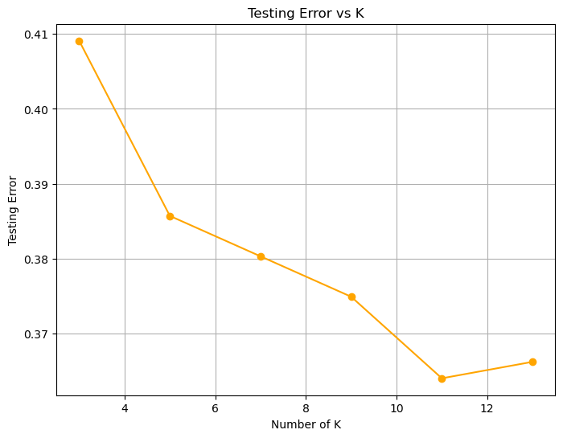

```python
import numpy as np
import matplotlib.pyplot as plt
from sklearn.neighbors import KNeighborsClassifier
from sklearn.model_selection import train_test_split
from sklearn.metrics import accuracy_score

np.random.seed(246010)

def generate_custom_data(n_samples):
    """
    Generates (x1, x2) from a uniform distribution [-1,1].
    Sets the probability P(Y = 1) using the given formula
    and generates binary labels.
    """
    X = np.random.uniform(-1, 1, (n_samples, 2))
    prob_y = 1 / (1 + np.exp(-X[:, 0] - X[:, 1]))
    y = np.random.binomial(1, prob_y)
    return X, y

# 2. Train and test KNN with different values of K
def knn_test(X_train, y_train, X_test, y_test, k_values):
    test_errors = []
    for k in k_values:
        knn = KNeighborsClassifier(n_neighbors=k)
        knn.fit(X_train, y_train)
        y_pred = knn.predict(X_test)
        test_error = 1 - accuracy_score(y_test, y_pred)
        test_errors.append(test_error)
    return test_errors

# 3. Plot the testing error as a function of K
def plot_knn_test_error(k_values, test_errors):
    plt.figure(figsize=(8, 6))
    plt.plot(k_values, test_errors, marker='o',
             linestyle='-', color='orange')
    plt.xlabel("Number of K")
    plt.ylabel("Testing Error")
    plt.title("Testing Error vs K")
    plt.grid(True)
    plt.show()

# Main function
def main():
    # Generate the custom dataset with 300 samples for training
    # and 10,000 for testing
    X_train, y_train = generate_custom_data(300)
    X_test, y_test = generate_custom_data(10000)

    # Define values of K up to 13 as shown in the image
    k_values = [3, 5, 7, 9, 11, 13]

    # Compute testing error for each value of K
    test_errors = knn_test(X_train, y_train, X_test, y_test, k_values)

    # Plot the testing error fluctuation
    plot_knn_test_error(k_values, test_errors)

# Run the main function
if __name__ == "__main__":
    main()
```